# Assignment 6

## Try to submit as an HTML file

Print your name below

```python
print("Daisy Cossio Garcia")
```

```
Daisy Cossio Garcia
```

Import the "pandas" and "matplotlib.pyplot" library

```python
# Write your answer here:
import pandas as pd
import matplotlib.pyplot as plt
```

(a) Compute function for each individual (map)

- Import the datset "data/investment.csv"
- Write a lambda function for $V = P/(1+r)$.
- Use `list(map(...))` to calculate $V$ for each row of the dataset

```python
# Write your own code here
investment=pd.read_csv('data/investment.csv')
fn_compute = lambda P,r: P/ (1 + r)
investment["V"] =list(map(fn_compute, investment["P"], investment["r"]))
investment
```

|  | P | r | V |
| --- | --- | --- | --- |
| 0 | 1000 | 0.01 | 990.099010 |
| 1 | 2000 | 0.02 | 1960.784314 |
| 2 | 500 | 0.03 | 485.436893 |
| 3 | 800 | 0.04 | 769.230769 |
| 4 | 400 | 0.08 | 370.370370 |

(b) Convert to upper case

- Create the following function to convert a string to upper case

$\quad$ `fn_upper = lambda x: x.upper()`

- Create a new column, "countryname_upper"

that converts "countryname" to upper case.

```python
# Write your own code here
wdi_2020 = pd.read_csv("data/wdi_2020.csv")
fn_upper = lambda x: x.upper()
wdi_2020["countryname_upper"] = list(map(fn_upper, wdi_2020["countryname"]))
wdi_2020
```

|  | year | yearcode | countryname | countrycode | prop_urbanpopulation | countryname_upper |
| --- | --- | --- | --- | --- | --- | --- |
| 0 | 2020 | YR2020 | Afghanistan | AFG | 26.026000 | AFGHANISTAN |
| 1 | 2020 | YR2020 | Africa Eastern and Southern | AFE | 36.828301 | AFRICA EASTERN AND SOUTHERN |
| 2 | 2020 | YR2020 | Africa Western and Central | AFW | 47.857831 | AFRICA WESTERN AND CENTRAL |
| 3 | 2020 | YR2020 | Albania | ALB | 62.112000 | ALBANIA |
| 4 | 2020 | YR2020 | Algeria | DZA | 73.733000 | ALGERIA |
| ... | ... | ... | ... | ... | ... | ... |
| 261 | 2020 | YR2020 | West Bank and Gaza | PSE | 76.719000 | WEST BANK AND GAZA |
| 262 | 2020 | YR2020 | World | WLD | 56.063764 | WORLD |
| 263 | 2020 | YR2020 | Yemen, Rep. | YEM | 37.908000 | YEMEN, REP. |
| 264 | 2020 | YR2020 | Zambia | ZMB | 44.629000 | ZAMBIA |
| 265 | 2020 | YR2020 | Zimbabwe | ZWE | 32.242000 | ZIMBABWE |

266 rows × 6 columns

For questions (b)-(d), read "data/wdi_2020.csv"

(c) Extract sorted elements from a dataset

- Sort by "prop_urbanpopulation" in descending order
- Subset the 5 countries with the highest urban population

```python
# Write your code here
wdi_20_sorted = wdi_2020.sort_values(by="prop_urbanpopulation", ascending=False)
display(wdi_20_sorted.iloc[0:5, :])
```

|  | year | yearcode | countryname | countrycode | prop_urbanpopulation | countryname_upper |
| --- | --- | --- | --- | --- | --- | --- |
| 212 | 2020 | YR2020 | Singapore | SGP | 100.0 | SINGAPORE |
| 147 | 2020 | YR2020 | Macao SAR, China | MAC | 100.0 | MACAO SAR, CHINA |
| 40 | 2020 | YR2020 | Cayman Islands | CYM | 100.0 | CAYMAN ISLANDS |
| 90 | 2020 | YR2020 | Gibraltar | GIB | 100.0 | GIBRALTAR |
| 103 | 2020 | YR2020 | Hong Kong SAR, China | HKG | 100.0 | HONG KONG SAR, CHINA |

(d) Subset elements with query

- Compute the median of "prop_urbanpopulation"
- Use ".query()" to subset countries with

"prop_urbanpopulation" above the median

```python
# Write your own code here
wdi_2020_median = wdi_2020["prop_urbanpopulation"].median(skipna=True)
print(wdi_2020_median)
wdi_2020_above_median = wdi_2020.query("prop_urbanpopulation >= @wdi_2020_median")
display(wdi_2020_above_median)
```

```
60.69872843
```

|  | year | yearcode | countryname | countrycode | prop_urbanpopulation | countryname_upper |
| --- | --- | --- | --- | --- | --- | --- |
| 3 | 2020 | YR2020 | Albania | ALB | 62.112000 | ALBANIA |
| 4 | 2020 | YR2020 | Algeria | DZA | 73.733000 | ALGERIA |
| 5 | 2020 | YR2020 | American Samoa | ASM | 87.153000 | AMERICAN SAMOA |
| 6 | 2020 | YR2020 | Andorra | AND | 87.916000 | ANDORRA |
| 7 | 2020 | YR2020 | Angola | AGO | 66.825000 | ANGOLA |
| ... | ... | ... | ... | ... | ... | ... |
| 254 | 2020 | YR2020 | Upper middle income | UMC | 67.601442 | UPPER MIDDLE INCOME |
| 255 | 2020 | YR2020 | Uruguay | URY | 95.515000 | URUGUAY |
| 258 | 2020 | YR2020 | Venezuela, RB | VEN | 88.279000 | VENEZUELA, RB |
| 260 | 2020 | YR2020 | Virgin Islands (U.S.) | VIR | 95.939000 | VIRGIN ISLANDS (U.S.) |
| 261 | 2020 | YR2020 | West Bank and Gaza | PSE | 76.719000 | WEST BANK AND GAZA |

132 rows × 6 columns

(e) Plot by category

- Read "data/wdi_urban.csv"

This contains data from 1980 and 2020

- Create a list with the unique values of "year"
- Create a plot with a ...
  - Histogram of "prop_urbanpopulation"

  for each year
  - Set the histogram option `alpha = 0.5` for transparency
  - All the histograms should be overlapping
  - Create a legend with the list of years
  - Label the axes and the title

What do we learn from the graph?

HINT: See the example at the end of Lecture 10

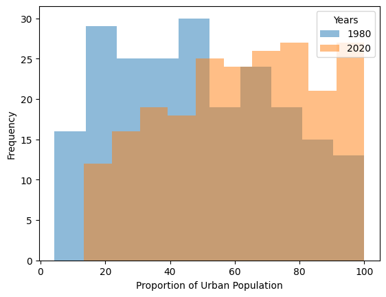

```python
# Write your own code here
wdi_urban = pd.read_csv("data/wdi_urban.csv")
year = pd.unique(wdi_urban["year"])

for i in year:
    df   = wdi_urban.query("year == @i")
    plt.hist(df["prop_urbanpopulation"], alpha = 0.5)

plt.xlabel("Proportion of Urban Population")
plt.ylabel("Frequency")
plt.legend(labels = year,
           title  = "Years")
plt.show()
```